# 911 Emergency Call - Descriptive Analysis

Data Source: [Kaggle](https://www.kaggle.com/mchirico/montcoalert).

Data Directory:

- lat : Latitude
- lng: Longitude
- desc: Description of the Emergency Call
- zip: Zipcode
- title: Title
- timeStamp: YYYY-MM-DD HH:MM:SS
- twp: Township
- addr: Address

Overview: A descriptive analysis on 911 Emergency Call Dataset.

## LOADING AND SETUP

In this descriptive analysis, I basically use the following four packages of python: numpy, pandas, matplotlib, and seaborn

```python
import numpy as np
import pandas as pd
import matplotlib.pyplot as plt
import seaborn as sns
%matplotlib inline
```

```python
df = pd.read_csv('911.csv')
```

Here is the basic info of this dataset

```python
df.info()
```

```
<class 'pandas.core.frame.DataFrame'>
RangeIndex: 99492 entries, 0 to 99491
Data columns (total 9 columns):
lat          99492 non-null float64
lng          99492 non-null float64
desc         99492 non-null object
zip          86637 non-null float64
title        99492 non-null object
timeStamp    99492 non-null object
twp          99449 non-null object
addr         98973 non-null object
e            99492 non-null int64
dtypes: float64(3), int64(1), object(5)
memory usage: 6.8+ MB
```

```python
df.head(3)
```

|  | lat | lng | desc | zip | title | timeStamp | twp | addr | e |
| --- | --- | --- | --- | --- | --- | --- | --- | --- | --- |
| 0 | 40.297876 | -75.581294 | REINDEER CT & DEAD END; NEW HANOVER; Station ... | 19525.0 | EMS: BACK PAINS/INJURY | 2015-12-10 17:40:00 | NEW HANOVER | REINDEER CT & DEAD END | 1 |
| 1 | 40.258061 | -75.264680 | BRIAR PATH & WHITEMARSH LN; HATFIELD TOWNSHIP... | 19446.0 | EMS: DIABETIC EMERGENCY | 2015-12-10 17:40:00 | HATFIELD TOWNSHIP | BRIAR PATH & WHITEMARSH LN | 1 |
| 2 | 40.121182 | -75.351975 | HAWS AVE; NORRISTOWN; 2015-12-10 @ 14:39:21-St... | 19401.0 | Fire: GAS-ODOR/LEAK | 2015-12-10 17:40:00 | NORRISTOWN | HAWS AVE | 1 |

# Quick Numbers

The top 5 ZIP area with most emengercy calls

```python
df['zip'].value_counts().head(5)
```

```
19401.0    6979
19464.0    6643
19403.0    4854
19446.0    4748
19406.0    3174
Name: zip, dtype: int64
```

The top 5 town with most emengercy calls

```python
df['twp'].value_counts().head(5)
```

```
LOWER MERION    8443
ABINGTON        5977
NORRISTOWN      5890
UPPER MERION    5227
CHELTENHAM      4575
Name: twp, dtype: int64
```

# Explore type of emergency call

```python
# Since the title column in this original dataset describe: Reasons/Department information, here I seperate the reason
df['Reason'] = df['title'].apply(lambda x:x.split('/')[0]).apply(lambda x:x.split(':')[0])
```

```python
df['Reason'].value_counts()
```

```
EMS        48877
Traffic    35695
Fire       14920
Name: Reason, dtype: int64
```

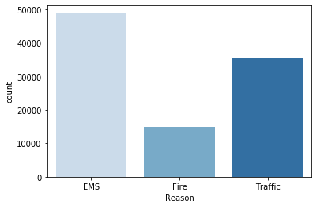

```python
sns.countplot(x='Reason',data=df, palette='Blues')
```

# Explore the Time Effect

```python
# check the timeStamp data type
type(df['timeStamp'].iloc[0])
```

```
str
```

```python
# convert the string data to time data
df['timeStamp'] = pd.to_datetime(df['timeStamp'])
```

```python
# Create 3 seperate column that capture the day of week, the month, and the exactly hour of time.
df['Day of Week'] = df['timeStamp'].apply(lambda date:date.dayofweek)
df['Month'] = df['timeStamp'].apply(lambda date:date.month)
df['Hour'] = df['timeStamp'].apply(lambda date:date.hour)
dmap = {0:'Mon',1:'Tue',2:'Wed',3:'Thu',4:'Fri',5:'Sat',6:'Sun'}
df['Day of Week'] = df['Day of Week'].map(dmap)
```

See which day of week receive the call most frequently.

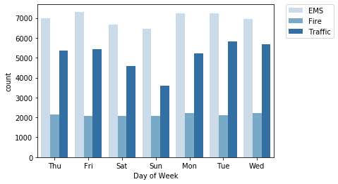

```python
sns.countplot(x='Day of Week',data=df,hue='Reason',palette='Blues')
plt.legend(bbox_to_anchor=(1.05, 1), loc=2, borderaxespad=0.)
```

It turns out that call concerning fire emergency has the least number in any of the day, and call concerning EMS has the highest number in any of the day. For call concerning traffic, numbers are low during weekends than weekdays.

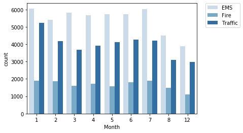

```python
sns.countplot(x='Month',data=df,hue='Reason',palette='Blues')
# To relocate the legend
plt.legend(bbox_to_anchor=(1.05, 1), loc=2, borderaxespad=0.)
```

I observed that there is missing month, so I plot the following line chart to indicate the month trend.

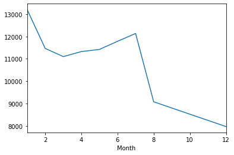

```python
dfnew = df.groupby('Month').count()
dfnew['desc'].plot()
```

It seems that during the last months of a year, the number of emergency calls decreased a lot. (SO FUN)

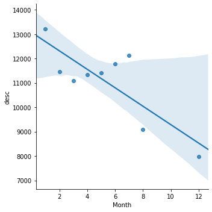

```python
dfmonth = dfnew.reset_index()
sns.lmplot(x='Month',y='desc',data=dfmonth)
```

A linear regression also proves the data trend.

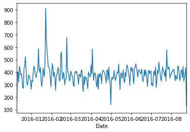

```python
df['Date'] = df['timeStamp'].apply(lambda x:x.date())
dfdate = df.groupby('Date').count()
dfdate['desc'].plot()
```

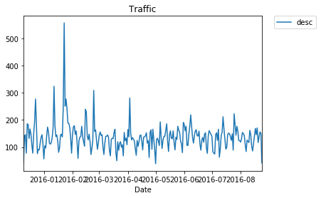

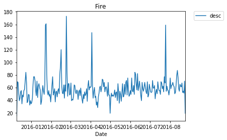

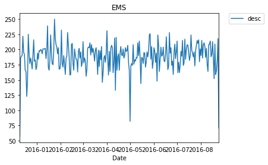

```python
dfdatediff = df.groupby(['Date','Reason']).count()
dfhhh = dfdatediff.reset_index()

dfhhh[dfhhh['Reason']=='Traffic'].plot(x='Date',y='desc',title='Traffic')
plt.legend(bbox_to_anchor=(1.05, 1), loc=2, borderaxespad=0.)

dfhhh[dfhhh['Reason']=='Fire'].plot(x='Date',y='desc',title='Fire')
plt.legend(bbox_to_anchor=(1.05, 1), loc=2, borderaxespad=0.)

dfhhh[dfhhh['Reason']=='EMS'].plot(x='Date',y='desc',title='EMS')
plt.legend(bbox_to_anchor=(1.05, 1), loc=2, borderaxespad=0.)
```

# Is the number of calls differ during differnt hour and day of week?

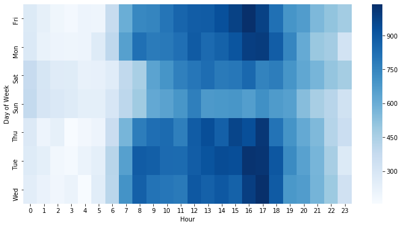

```python
dfdayhour = df.groupby(['Day of Week','Hour']).count()['Reason'].unstack()
plt.figure(figsize=(12,6))
sns.heatmap(data=dfdayhour,cmap='Blues')
```

Seems that emergency call happens a lot during 4pm to 6pm! Why? Is it because traffic?

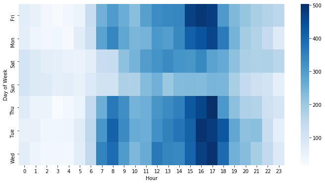

```python
dftriffdayhour = df[df['Reason']=='Traffic'].groupby(['Day of Week','Hour']).count()['Reason'].unstack()
plt.figure(figsize=(12,6))
sns.heatmap(data=dftriffdayhour,cmap='Blues')
```

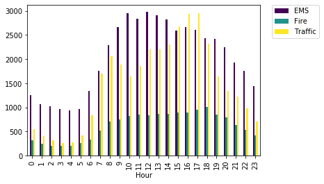

```python
dfnumber = df.groupby(['Hour','Reason']).count()['desc'].unstack()
plt.figure(figsize=(20,10))
dfnumber.plot(lw=20,kind='bar',colormap='viridis')
plt.legend(bbox_to_anchor=(1.05, 1), loc=2, borderaxespad=0.)
```

From 4pm-6pm, the number of traffic report are really high!